# UseCase_LogisticRonSpirals

Henri Funk

2 12 2020

# Examples

```r
posterior_density = mvtnorm::dmvnorm
gradient <- function(position){-position}
sample50norm <- sample_noUturn(position_init = runif(50, -5, -2), iteration = 2e3, is_log = FALSE)
```

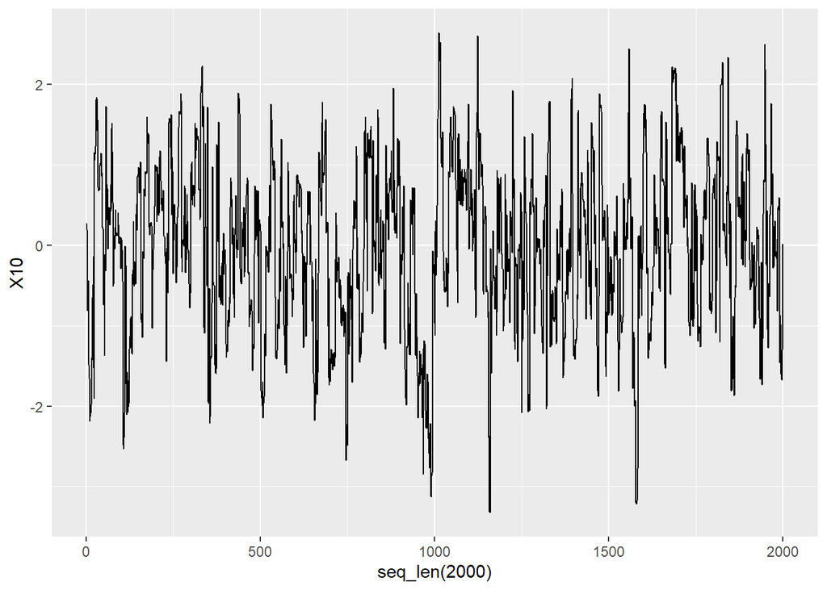

```r
ggplot(data = sample50norm, aes(x = seq_len(2000), y = X10)) +
  geom_line()
```

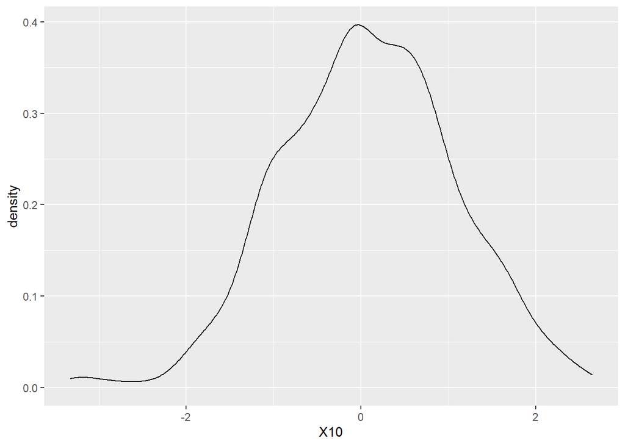

```r
ggplot(data = sample50norm[-seq_len(1e3), ], aes(x = X10)) +
  geom_density()
```

```r
attrib_mnd <- attributes(sample50norm)
knitr::kable(table(attrib_mnd$tree_depth), col.names = c("tree_depth", "freq"))
```

| tree_depth | freq |
| --- | --- |
| 2 | 1 |
| 4 | 1 |
| 5 | 1 |
| 6 | 1 |
| 7 | 1992 |
| 8 | 4 |

```r
attrib_mnd$dual_averaging$stepsize_weight[1000]
```

```
## [1] 0.01533517
```

## SetUp Experiment

A data frame with 79 rows and 4 variables: **NV** Neovasculation risk factor indicator (0=Absent, 1=Present)  
**PI** Pulsatility index of arteria uterina  
**EH** Endometrium height

We standardize all of the features

```r
library(hmclearn)
data(Endometrial)


# data prep
Endometrial$PI2 <- with(Endometrial, (PI - mean(PI)) / sd(PI))
Endometrial$EH2 <- with(Endometrial, (EH - mean(EH)) / sd(EH))
Endometrial$NV2 <- Endometrial$NV - 0.5

X <- cbind(1, as.matrix(Endometrial[, which(colnames(Endometrial)
            %in% c("PI2", "EH2", "NV2"))]))
y <- Endometrial$HG

colnames(X) <- c("(Intercept)", "PI2", "EH2", "NV2")
```

## Define posterior and gradient function

```r
devtools::load_all()
```

```
## Loading NoUTurn
```

```r
posterior_density = bernoulli_pen
gradient = partial_deriv_sigmoid
```

$$\begin{aligned}
f(\mathbf{y} | \mathbf{X},\boldsymbol\beta) &= \prod_{i=1}^n p^{y_i} (1-p)^{1-y_i}, \\
&= \prod_{i=1}^{n} \left(\frac{1}{1+e^{-\mathbf{x}i^T\boldsymbol\beta}}\right)^{y_i} \left(\frac{e^{-\mathbf{x}_i^T\boldsymbol\beta}}{1+e^{-\mathbf{x}_i^T\boldsymbol\beta}}\right)^{1-y_i}, \\
\log f(\mathbf{y} | \mathbf{X}, \boldsymbol\beta) &= \sum{i=1}^n -y_i\log(1+e^{-\mathbf{x}i^T\boldsymbol\beta}) + (1-y_i)(-\mathbf{x}_i\boldsymbol\beta - \log(1+e^{-\mathbf{x}_i^T\boldsymbol\beta})), \\
&= \sum{i=1}^n -\log(1+e^{-\mathbf{x}i\boldsymbol\beta}) - \mathbf{x}_i^T\boldsymbol\beta(1 - y_i), \\
&= \sum{i=1}^n \mathbf{x}_i^T\boldsymbol\beta(y_i - 1) - \log(1 + e^{-\mathbf{x}_i^T\boldsymbol\beta}), \\
&= \boldsymbol\beta^T\mathbf{X}^T(\mathbf{y} - \mathbf{1}_n) - \mathbf{1}_n^T [ \log( 1 + e^{-\mathbf{X}\boldsymbol\beta})].
\end{aligned}$$

We set a multivariate normal prior for $\boldsymbol\beta$

$$\begin{aligned} \boldsymbol\beta &\sim N(0, \sigma^2 \mathbf{I}), \end{aligned}$$

with pdf, omitting constants

$$\begin{aligned}
\pi(\boldsymbol\beta | \sigma^2) &= \frac{1}{\sqrt{\lvert 2\pi \sigma^2 \rvert }}e^{-\frac{1}{2}\boldsymbol\beta^T \boldsymbol\beta / \sigma^2}, \\
\log \pi(\boldsymbol\beta | \sigma^2) &= -\frac{1}{2}\log(2\pi \sigma^2) - \frac{1}{2}\boldsymbol\beta^T \boldsymbol\beta / \sigma^2, \\
&\propto -\frac{1}{2}\log \sigma^2 - \frac{\boldsymbol\beta^T\boldsymbol\beta}{2\sigma^2}.
\end{aligned}$$

Next, we derive the log posterior, omitting constants,

$$\begin{aligned}
f(\boldsymbol\beta | \mathbf{X}, \mathbf{y}, \sigma^2) &\propto f(\mathbf{y} | \mathbf{X}, \boldsymbol\beta) \pi(\boldsymbol\beta | \sigma^2), \\
\log f(\boldsymbol\beta | \mathbf{X}, \mathbf{y}, \sigma^2) & \propto \log f(\mathbf{y} | \mathbf{X}, \boldsymbol\beta) + \log \pi(\boldsymbol\beta|\sigma^2), \\
&\propto \sum_{i=1}^n \mathbf{x}i^T\boldsymbol\beta(y_i - 1) - \log(1 + e^{-\mathbf{x}_i^T\boldsymbol\beta}) - \frac{1}{2}\boldsymbol\beta^T\boldsymbol\beta / \sigma^2, \\
&\propto \boldsymbol\beta^T\mathbf{X}^T(\mathbf{y} - \mathbf{1}n) - \mathbf{1}_n^T[\log( 1 + e^{-\mathbf{X}\boldsymbol\beta})] - \frac{\boldsymbol\beta^T\boldsymbol\beta}{2\sigma^2}.
\end{aligned}$$

We use a GAM with 2 position estimates indicating sinus of their true position here to consider spirals nonlinear structure.

```r
initial_pos <- lapply(1:5, function(x) runif(9, -5, 5))
param_sample_binary <- lapply(initial_pos, sample_noUturn, iteration = 5e3, design = design, target = target, is_log = TRUE, seed = 123L, target_accpentance = .39, max_tree_depth = 12L)
```

## Check for convergence

Trace Plot for parameters

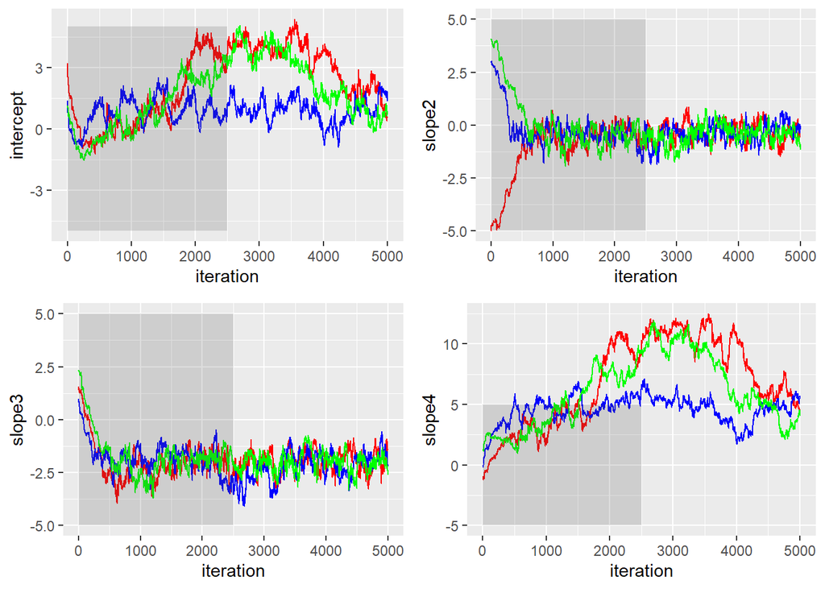

```r
calculate_traceplots <- function(var, varname, iter = 5e3){
  ggplot(data = param_sample_binary[[1]], aes_string(x = seq_len(iter), y = var)) +
    geom_line(color = "red") + labs(x = "iteration", y = varname) +
    geom_line(data =param_sample_binary[[2]],
            aes_string(x = seq_len(iter), y = var), color = "blue") +
    geom_line(data =param_sample_binary[[3]],
            aes_string(x = seq_len(iter), y = var), color = "green") +
    annotate("rect", xmin = 0, xmax = 2500, ymin = -5, ymax = 5, alpha = .2)
}

args <- list(
  list(var = "X1", varname = "intercept"), list(var = "X2", varname = "slope2"),
  list(var = "X3", varname = "slope3"), list(var = "X4", varname = "slope4")
  )

traceplots <- lapply(args, function(x) do.call(calculate_traceplots, x))

do.call(grid.arrange, c(traceplots, nrow = 2))
```

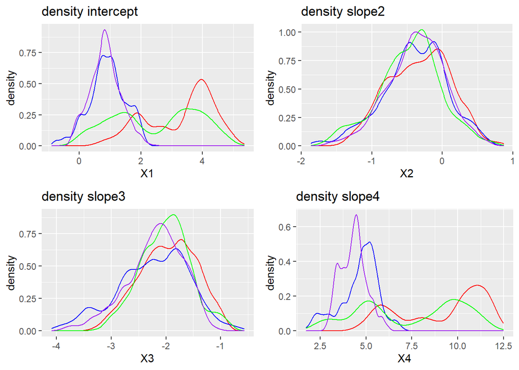

```r
param_distrib <- lapply(param_sample_binary, function(x){
  x[-seq_len(2500),]
})

calc_density_plots <- function(var, varname) {
  ggplot() +
    geom_density(data = param_distrib[[1]], aes_string(x = var), color = "red") +
    geom_density(data = param_distrib[[2]], aes_string(x = var), color = "blue") +
    geom_density(data = param_distrib[[3]], aes_string(x = var), color = "green") +
    geom_density(data = param_distrib[[4]], aes_string(x = var), color = "purple") +
    ggtitle(paste("density", varname))
}

density <- lapply(args, function(x)calc_density_plots(x$var, x$varname))
do.call(grid.arrange, c(density, nrow = 2))
```

GLM Comparison

```r
f <- glmnet::glmnet(X, y, family = "binomial", lambda = 1/200)


f$a0
```

```
##       s0
## 0.873365
```

```r
f$beta
```

```
## 4 x 1 sparse Matrix of class "dgCMatrix"
##                    s0
## (Intercept)  .
## PI2         -0.311247
## EH2         -1.804129
## NV2          4.144032
```

## Mean Estimation

```r
mean_estimate <- lapply(param_distrib, colMeans)

calc <- lapply(mean_estimate, function(x) {
  1- 1/(1+ exp(X %*% x))
})

lapply(calc, function(x){
  sum(y - x) / nrow(x)
})
```

```
## [[1]]
## [1] 0.005354494
##
## [[2]]
## [1] 0.01022067
##
## [[3]]
## [1] -0.007474229
##
## [[4]]
## [1] 0.0004641274
##
## [[5]]
## [1] 0.007668197
```

## Attributes

```r
attribs <- lapply(param_sample_binary, attributes)
lapply(attribs, function(x) knitr::kable(table(x$tree_depth)))
```

```
## [[1]]
##
##
## Var1    Freq
## -----  -----
## 1          2
## 2          2
## 3          3
## 4          2
## 5          3
## 6          1
## 8          1
## 9          1
## 10         1
## 11         6
## 12      4978
##
## [[2]]
##
##
## Var1    Freq
## -----  -----
## 2          2
## 3          1
## 4          1
## 5          1
## 6          2
## 7          1
## 10         3
## 11        11
## 12      4978
##
## [[3]]
##
##
## Var1    Freq
## -----  -----
## -1         1
## 1          2
## 3          1
```

[output cut: 25 more lines]

```
##
##
## Var1    Freq
## -----  -----
## -1         1
## 0          1
## 1          2
## 2          2
## 5          2
## 6          1
## 7          1
## 8          1
## 9          2
## 11         5
## 12      4982
```

```r
lapply(attribs, function(x) x$dual_averaging$stepsize_weight[2500])
```

```
## [[1]]
## [1] 1.201559e-05
##
## [[2]]
## [1] 8.740632e-06
##
## [[3]]
## [1] 9.676812e-06
##
## [[4]]
## [1] 1.08121e-05
##
## [[5]]
## [1] 1.017418e-05
```

# Regression

Data Set Information:

The data was retrieved from a set of 53500 CT images from 74 different patients (43 male, 31 female).

Each CT slice is described by two histograms in polar space. The first histogram describes the location of bone structures in the image, the second the location of air inclusions inside of the body. Both histograms are concatenated to form the final feature vector. Bins that are outside of the image are marked with the value -0.25.

The class variable (relative location of an image on the axial axis) was constructed by manually annotating up to 10 different distinct landmarks in each CT Volume with known location. The location of slices in between landmarks was interpolated.

Attribute Information:

1. patientId: Each ID identifies a different patient
2. - 241.: Histogram describing bone structures
3. - 385.: Histogram describing air inclusions
4. reference: Relative location of the image on the axial axis (class value). Values are in the range [0; 180] where 0 denotes the top of the head and 180 the soles of the feet.

```r
tmp <- tempfile()
download.file(
  "https://archive.ics.uci.edu/ml/machine-learning-databases/00206/slice_localization_data.zip",
  tmp)
ct_slice <- read.csv(unz(tmp, filename = "slice_localization_data.csv"), as.is = TRUE)
```

```r
id <- sample(seq_len(53500), 1e4)
trainCT <- ct_slice[id, ]
target <- trainCT[, 386]
design <- as.matrix(cbind(1, trainCT[, -386]))
c(min(target), max(target)) # -> map on real numbers, maybe gamma distrib...
```

```r
devtools::load_all()
posterior_density = gamma_distr
gradient = partial_deriv_gamma
```

```r
start <- Sys.time()
initial_pos <- lapply(1:3, function(x) c(runif(1), runif(386, 16, 18)))
sigmoid_parameter_distrib <- lapply(initial_pos, sample_noUturn, iteration = 10, design = design, target = target, is_log = TRUE, seed = 123L, target_accpentance = .65, max_tree_depth = 11L)
dif2000iter <- Sys.time() - start
dif2000iter
```